# Chapter 2 What a microsample looks like

Before any spatial analysis, we need a community table we can trust. This chapter builds one from raw mapping output and shows why micro-scale data needs a filtering step that ordinary metagenomics can skip.

## 2.1 The raw tables

Reads from each microsample were mapped against the catalogue of 223 genomes. That produces two tables of exactly the same shape.

```r
# how many reads from each microsample mapped to each genome
genome_read_counts[1:5, 1:4]
```

```
# A tibble: 5 × 4
  genome             M306662 M306663 M306664
  <chr>                <dbl>   <dbl>   <dbl>
1 D300418:bin_000001     284    1833     952
2 D300418:bin_000013      70     189     160
3 D300428:bin_000008      54     557     321
4 D300430:bin_000010   18507  100593   76089
5 D300432:bin_000001     210    1441     861
```

```r
# how many bases of each genome those reads covered
genome_covered_bases[1:5, 1:4]
```

```
# A tibble: 5 × 4
  genome             M306662 M306663 M306664
  <chr>                <dbl>   <dbl>   <dbl>
1 D300418:bin_000001   13008   13910   17974
2 D300418:bin_000013    2573    3754    4827
3 D300428:bin_000008    4385   19153   15907
4 D300430:bin_000010 1067323 2259902 2364991
5 D300432:bin_000001    8428   12083   12304
```

```r
dim(genome_read_counts)   # genomes x (1 + microsamples)
```

```
[1] 223 337
```

And a table describing the microsamples themselves:

```r
sample_metadata %>%
  select(microsample, cryosection, region, Xcoord, Ycoord, distance_host,
         after_filtering.total_bases) %>%
  head()
```

```
# A tibble: 6 × 7
  microsample cryosection region Xcoord Ycoord distance_host
  <chr>       <chr>       <chr>   <dbl>  <dbl>         <dbl>
1 M306662     G121eO306A  Colon  39437. 18262.          233.
2 M306663     G121eO306A  Colon  39668. 18540.          448.
3 M306664     G121eO306A  Colon  39839. 18989.          562.
4 M306666     G121eO306A  Colon  39567. 19394.          262.
5 M306667     G121eO306A  Colon  39610. 19673.          213.
6 M306668     G121eO306A  Colon  40115. 19732.          642.
# ℹ 1 more variable: after_filtering.total_bases <dbl>
```

`Xcoord` and `Ycoord` are the position of the microsample on the cryosection in micrometres. `distance_host` is how far it sits from the epithelium — the gut wall — which is the gradient we will eventually be testing against.

**Scale check.** A microsample covers a few hundred micrometres. The whole cryosection is a couple of millimetres across. The 168 microsamples of one section together weigh less than a grain of salt.

## 2.2 Sequencing depth is data here, not a nuisance

The introduction described the unnormalised pooling protocol. You can verify it in the metadata: every microsample was cut to the same area and given the same number of PCR cycles.

```r
sample_metadata %>%
  count(cryosection, size, cycles, name = "microsamples")
```

```
# A tibble: 2 × 4
  cryosection  size cycles microsamples
  <chr>       <dbl>  <dbl>        <int>
1 G121eI117A   5000     15          168
2 G121eO306A   5000     15          168
```

Identical input area, identical amplification, no equimolar normalisation. So how much do the resulting library sizes differ?

```r
sample_metadata %>%
  group_by(cryosection) %>%
  summarise(
    total_Gb   = round(sum(after_filtering.total_bases) / 1e9, 1),
    min_Mb     = round(min(after_filtering.total_bases) / 1e6, 1),
    median_Mb  = round(median(after_filtering.total_bases) / 1e6, 1),
    max_Mb     = round(max(after_filtering.total_bases) / 1e6, 1),
    fold_range = round(max(after_filtering.total_bases) /
                       min(after_filtering.total_bases)),
    .groups = "drop"
  )
```

```
# A tibble: 2 × 6
  cryosection total_Gb min_Mb median_Mb max_Mb fold_range
  <chr>          <dbl>  <dbl>     <dbl>  <dbl>      <dbl>
1 G121eI117A     1040.   43.5     5671. 18221.        419
2 G121eO306A      749.   23.1     3744. 31585.       1366
```

A **400- to 1,400-fold** spread, between pieces of tissue of identical size processed identically. Under equimolar pooling this range would have been flattened to near-uniform by design. Here it survives, and the most plausible thing it reflects is how much microbial biomass each microsample contained.

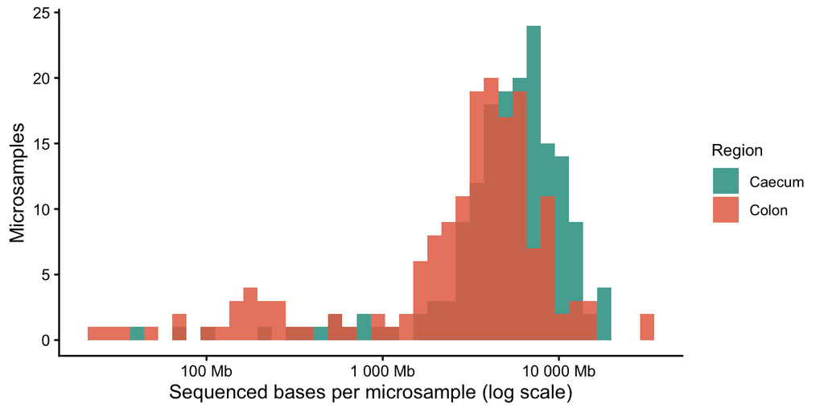

```r
ggplot(sample_metadata,
       aes(x = after_filtering.total_bases, fill = region)) +
  geom_histogram(bins = 40, alpha = 0.85, position = "identity") +
  scale_x_log10(labels = scales::label_number(scale = 1e-6, suffix = " Mb")) +
  scale_fill_manual(values = region_colors) +
  labs(x = "Sequenced bases per microsample (log scale)",
       y = "Microsamples", fill = "Region")
```

Keep this in mind for the rest of the practical. When sequencing depth turns up as a strong predictor in Chapter 3, the reflex from ordinary metagenomics — *that is a technical artefact, control for it* — is the wrong reflex. Under this protocol it is a biological quantity in disguise.

It is not a clean one, though. Depth also determines how many genomes you can possibly detect, so richness and depth are confounded by construction. We will see exactly how strongly in a moment.

## 2.3 Why micro-scale data needs a coverage filter

Each microsample contains very little DNA, so it is sequenced shallowly. Look at how many genomes appear to be present in a typical microsample if we simply count non-zero entries:

```r
naive_present <- colSums(genome_read_counts[, -1] > 0)

summary(naive_present)
```

```
   Min. 1st Qu.  Median    Mean 3rd Qu.    Max.
  168.0   221.0   222.0   220.2   222.0   223.0
```

Almost every genome in the catalogue picks up *some* reads in *some* microsample. That cannot all be real. Short read mapping is a heuristic: a read from a genome that is genuinely present will also align, imperfectly, to its relatives. Those stray reads land scattered across the wrong genome.

That scattering is what lets us tell the two cases apart. A genome that is really there gets covered **evenly along its length**; a genome that only catches stray reads gets a few isolated patches. So instead of asking *how many reads*, we ask *how much of the genome was covered*.

```r
genome_coverage <- breadth_of_coverage(genome_covered_bases, genome_metadata)

genome_coverage[1:5, 1:4]
```

```
# A tibble: 5 × 4
  genome             M306662 M306663 M306664
  <chr>                <dbl>   <dbl>   <dbl>
1 D300418:bin_000001 0.00726 0.00777 0.0100
2 D300418:bin_000013 0.00110 0.00161 0.00207
3 D300428:bin_000008 0.00228 0.00996 0.00827
4 D300430:bin_000010 0.356   0.753   0.788
5 D300432:bin_000001 0.00302 0.00432 0.00440
```

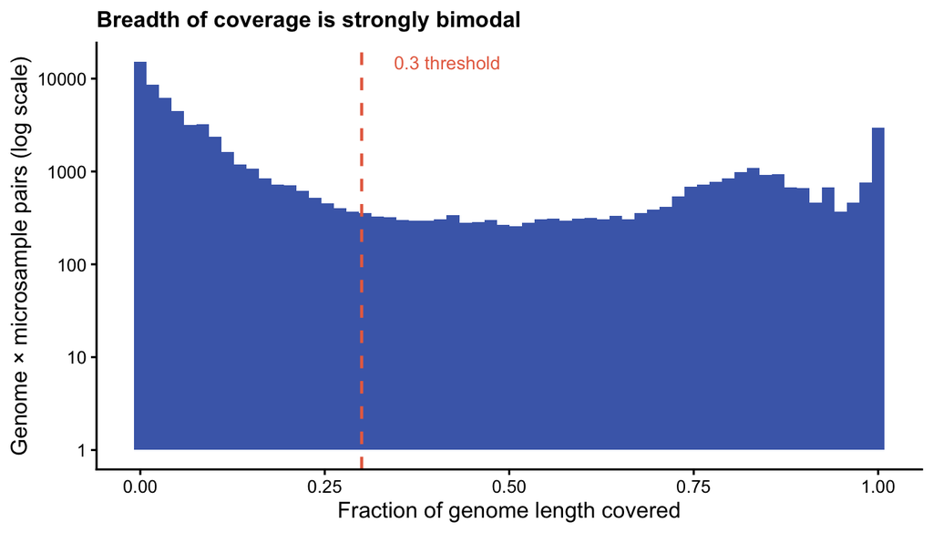

```r
coverage_long <- genome_coverage %>%
  pivot_longer(-genome, names_to = "microsample", values_to = "coverage") %>%
  filter(coverage > 0)

ggplot(coverage_long, aes(x = coverage)) +
  geom_histogram(bins = 60, fill = "#4a6ab7", colour = NA) +
  geom_vline(xintercept = 0.3, linetype = "dashed", colour = "#E76F51",
             linewidth = 0.8) +
  annotate("text", x = 0.33, y = Inf, label = "  0.3 threshold",
           hjust = 0, vjust = 2, colour = "#E76F51", size = 3.5) +
  scale_y_log10() +
  labs(x = "Fraction of genome length covered",
       y = "Genome × microsample pairs (log scale)",
       title = "Breadth of coverage is strongly bimodal")
```

## 2.4 Filtering and normalising

Two operations turn the raw table into a community table.

**Coverage filtering** zeroes out any genome–microsample pair below the threshold:

```r
read_counts_filt <- filter_by_coverage(genome_read_counts, genome_coverage,
                                       min_coverage = 0.3)

tibble(
  step = c("before filtering", "after filtering"),
  nonzero_entries = c(sum(genome_read_counts[, -1] > 0),
                      sum(read_counts_filt[, -1] > 0)),
  reads_kept_pct = c(100, round(100 * sum(read_counts_filt[, -1]) /
                                  sum(genome_read_counts[, -1]), 1))
)
```

```
# A tibble: 2 × 3
  step             nonzero_entries reads_kept_pct
  <chr>                      <int>          <dbl>
1 before filtering           73991          100
2 after filtering            22263           92.6
```

Note what happened: most *entries* are discarded, but almost all *reads* are kept. The filter removes a huge number of near-empty cells that were carrying very little signal.

**Length normalisation** converts read counts into genome counts. A 6 Mb genome captures twice as many reads as a 3 Mb genome at equal abundance, so we divide by genome length expressed in reads:

```r
genome_counts <- to_genome_counts(read_counts_filt, genome_metadata,
                                  read_length = 150)

genome_counts[1:5, 1:4]
```

```
# A tibble: 5 × 4
  genome             M306662 M306663 M306664
  <chr>                <dbl>   <dbl>   <dbl>
1 D300418:bin_000001   0        0       0
2 D300418:bin_000013   0        0       0
3 D300428:bin_000008   0        0       0
4 D300430:bin_000010   0.925    5.03    3.80
5 D300432:bin_000001   0        0       0
```

**Why not rarefy?** Rarefying subsamples every microsample down to a common depth. That would throw away exactly the quantity this protocol went to trouble to preserve — the depth differences that track biomass — and it would still leave the *within*-microsample counts compositional. Chapter 3 instead splits the problem in two: a log-ratio transformation for what the community is made of, and depth kept as its own variable for how much of it there was.

## 2.5 Diversity per microsample

With a community table we can ask how diverse each microsample is. We use Hill numbers, which put richness and evenness on the same scale (effective number of genomes):

```r
diversity <- alpha_diversity(genome_counts, genome_tree)

sample_metadata <- sample_metadata %>%
  left_join(diversity, by = "microsample")

sample_metadata %>%
  group_by(region) %>%
  summarise(
    microsamples  = n(),
    richness      = median(richness),
    neutral       = round(median(neutral), 1),
    phylogenetic  = round(median(phylogenetic), 1),
    .groups = "drop"
  )
```

```
# A tibble: 2 × 5
  region microsamples richness neutral phylogenetic
  <chr>         <int>    <dbl>   <dbl>        <dbl>
1 Caecum          168     76      37.1          3.9
2 Colon           168     68.5    35.1          3.8
```

| Metric | q | Reads as |
| --- | --- | --- |
| `richness` | 0 | how many genomes are present |
| `neutral` | 1 | how many genomes are *effectively* present, weighting by abundance |
| `phylogenetic` | 1 | same, but close relatives count as partly redundant |

Richness far above neutral diversity means a microsample is dominated by a few genomes with a long rare tail — which is exactly what these communities look like.

And here is the confounding promised above:

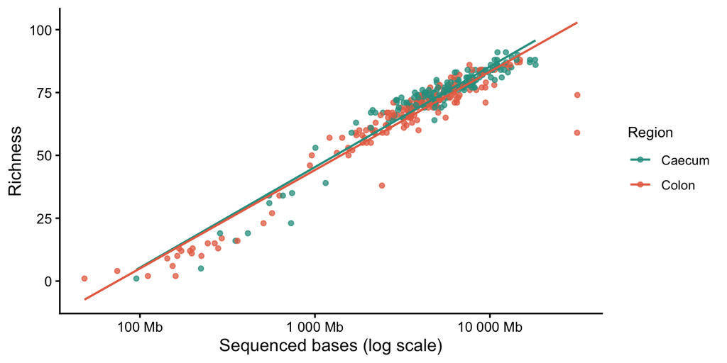

```r
sample_metadata %>%
  filter(richness > 0) %>%
  ggplot(aes(x = after_filtering.total_bases, y = richness, colour = region)) +
  geom_point(size = 1.3, alpha = 0.75) +
  geom_smooth(method = "lm", se = FALSE, linewidth = 0.7) +
  scale_x_log10(labels = scales::label_number(scale = 1e-6, suffix = " Mb")) +
  scale_colour_manual(values = region_colors) +
  labs(x = "Sequenced bases (log scale)", y = "Richness", colour = "Region")
```

```r
sample_metadata %>%
  filter(richness > 0) %>%
  group_by(region) %>%
  summarise(spearman_rho = round(cor(richness,
                                     log(after_filtering.total_bases),
                                     method = "spearman"), 2),
            .groups = "drop")
```

```
# A tibble: 2 × 2
  region spearman_rho
  <chr>         <dbl>
1 Caecum         0.94
2 Colon          0.93
```

ρ above 0.9. Two mechanisms produce that, and this dataset cannot separate them: a microsample with more biomass genuinely holds more genomes, **and** a microsample sequenced more deeply detects more of whatever it holds. Both are real; neither can be switched off. Any claim resting on richness alone in this kind of data is on thin ice.

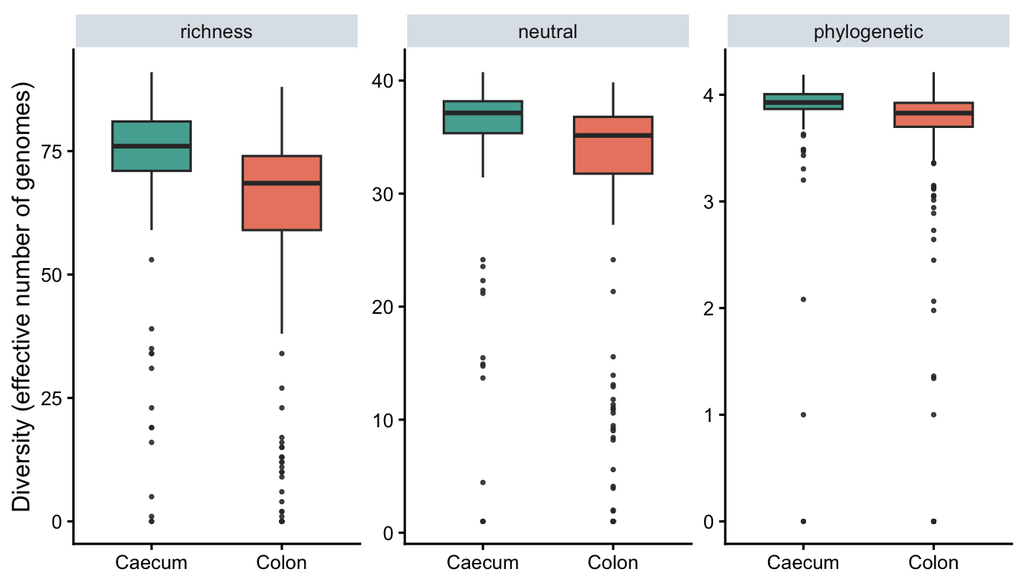

```r
sample_metadata %>%
  pivot_longer(c(richness, neutral, phylogenetic),
               names_to = "metric", values_to = "diversity") %>%
  mutate(metric = factor(metric,
                         levels = c("richness", "neutral", "phylogenetic"))) %>%
  ggplot(aes(x = region, y = diversity, fill = region)) +
  geom_boxplot(outlier.size = 0.6, width = 0.6, alpha = 0.85) +
  facet_wrap(~ metric, scales = "free_y") +
  scale_fill_manual(values = region_colors, guide = "none") +
  labs(x = NULL, y = "Diversity (effective number of genomes)")
```

## 2.6 Who is actually there

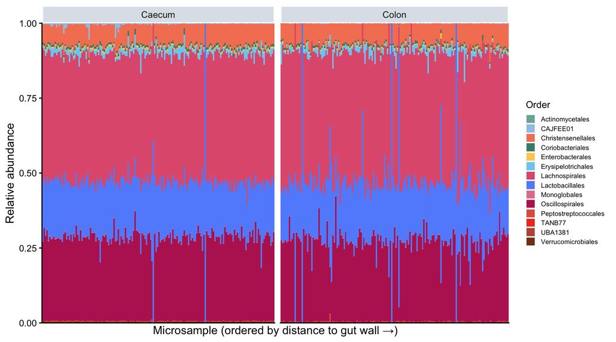

```r
composition <- genome_counts %>%
  pivot_longer(-genome, names_to = "microsample", values_to = "count") %>%
  group_by(microsample) %>%
  mutate(rel = count / sum(count)) %>%
  ungroup() %>%
  left_join(genome_metadata %>% select(genome, phylum, order),
            by = "genome") %>%
  left_join(sample_metadata %>% select(microsample, region, distance_host),
            by = "microsample") %>%
  filter(rel > 0)

composition %>%
  # order microsamples by distance to the gut wall, the gradient of interest
  mutate(microsample = fct_reorder(microsample, distance_host)) %>%
  ggplot(aes(x = microsample, y = rel, fill = order)) +
  geom_col(width = 1) +
  facet_grid(~ region, scales = "free_x", space = "free_x") +
  scale_fill_manual(values = order_colors) +
  scale_y_continuous(expand = c(0, 0)) +
  labs(x = "Microsample (ordered by distance to gut wall →)",
       y = "Relative abundance", fill = "Order") +
  theme(axis.text.x = element_blank(), axis.ticks.x = element_blank(),
        legend.key.size = unit(0.35, "cm"), legend.text = element_text(size = 7))
```